# Activity Monitoring

Michael Harrison

February 22, 2017

It is now possible to collect a large amount of data about personal movement using activity monitoring devices such as a Fitbit, Nike Fuelband, or Jawbone Up. These type of devices are part of the “quantified self” movement – a group of enthusiasts who take measurements about themselves regularly to improve their health, to find patterns in their behavior, or because they are tech geeks. But these data remain under-utilized both because the raw data are hard to obtain and there is a lack of statistical methods and software for processing and interpreting the data.

This analysis makes use of data from a personal activity monitoring device. This device collects data at 5 minute intervals through out the day. The data consists of two months of data from an anonymous individual collected during the months of October and November, 2012 and include the number of steps taken in 5 minute intervals each day.

The analysis is as proceeds:

## Reading in the data:

```r
activity <- read.csv("activity.csv")
head(activity)
```

```
##   steps       date interval
## 1    NA 2012-10-01        0
## 2    NA 2012-10-01        5
## 3    NA 2012-10-01       10
## 4    NA 2012-10-01       15
## 5    NA 2012-10-01       20
## 6    NA 2012-10-01       25
```

## Steps per day summary:

#### Total number of steps taken each day:

```r
library(dplyr); library(xtable)
activity <- tbl_df(activity)
totalsteps <- activity %>%
        group_by(date) %>%
        summarise(sumsteps = sum(steps, omit.na = TRUE))
print(xtable::xtable(head(totalsteps, n=10), caption = "Total Steps per Day"),
      type = "html", html.table.attributes = "border='1'", include.rownames = FALSE)
```

Total Steps per Day

| date | sumsteps |
| --- | --- |
| 2012-10-01 |  |
| 2012-10-02 | 127 |
| 2012-10-03 | 11353 |
| 2012-10-04 | 12117 |
| 2012-10-05 | 13295 |
| 2012-10-06 | 15421 |
| 2012-10-07 | 11016 |
| 2012-10-08 |  |
| 2012-10-09 | 12812 |
| 2012-10-10 | 9901 |

#### Histogram of steps taken daily:

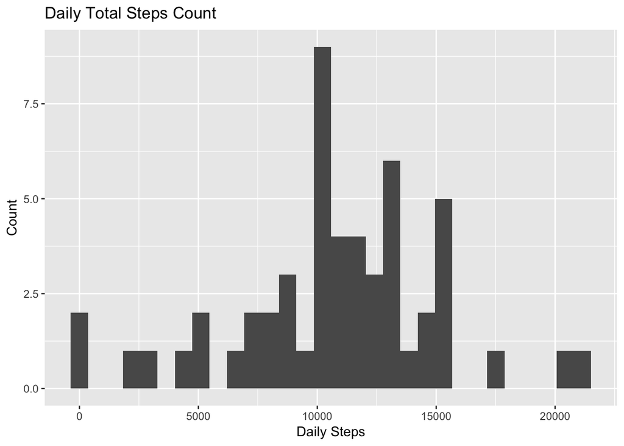

```r
library(ggplot2)
qplot(sumsteps, data = totalsteps,
      main = "Daily Total Steps Count", xlab = "Daily Steps", ylab = "Count")
```

#### Average steps per day:

```r
mean(totalsteps$sumsteps, na.rm = TRUE)
```

```
## [1] 10767.19
```

#### Median steps per day:

```r
median(totalsteps$sumsteps, na.rm = TRUE)
```

```
## [1] 10766
```

## Average Daily Activity

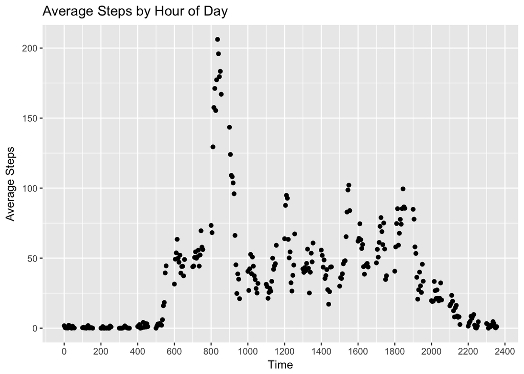

```r
timeseries <- activity %>%
        group_by(interval) %>%
        summarise(timesteps = mean(steps, na.rm=TRUE))

ggplot(timeseries) +
        geom_point(aes(interval, timesteps)) +
        scale_x_continuous(breaks = seq(0, 2400, by = 200)) +
        labs(title = "Average Steps by Hour of Day", x = "Time", y = "Average Steps")
```

#### Most active time interval

```r
timeseries[which(timeseries$timesteps == max(timeseries$timesteps)),]
```

```
## # A tibble: 1 × 2
##   interval timesteps
##      <int>     <dbl>
## 1      835  206.1698
```

## Missing Values

#### Number of missing values in data:

```r
sum(is.na(activity$steps))
```

```
## [1] 2304
```

#### Filling in NA values

Using the mean number of steps taken from the original data by the interval time period of the day, the NA values in the steps column of the dataframe were filled.

```r
int_med <- activity %>%
        group_by(interval) %>%
        summarise(steps = mean(steps, na.rm = TRUE))

filled_df <- activity

filled_df$steps <- ifelse(is.na(filled_df$steps) == TRUE,
                          int_med$steps[int_med$interval %in% filled_df$interval],
                          filled_df$steps)

sum(is.na(filled_df$steps))
```

```
## [1] 0
```

#### Histogram of steps taken daily (with NA values filled):

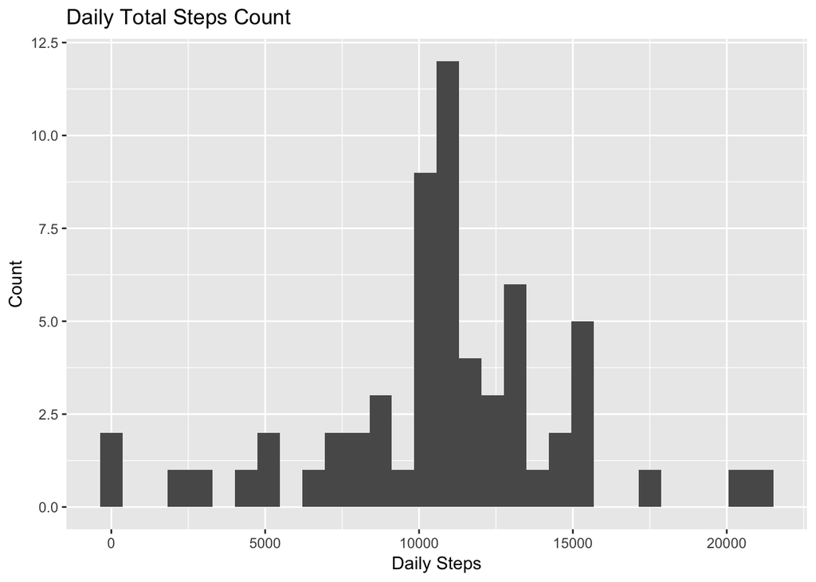

```r
filled_df <- filled_df %>%
        group_by(date) %>%
        summarise(steps = sum(steps))
qplot(steps, data = filled_df,
      main = "Daily Total Steps Count", xlab = "Daily Steps", ylab = "Count")
```

#### Average steps of NA filled data set

```r
mean(filled_df$steps)
```

```
## [1] 10766.19
```

#### Median of NA filled data set

```r
median(filled_df$steps)
```

```
## [1] 10766.19
```

From returned histogram and summary data based on dataset with NA values filled with step means by interval, the data does not appear to change the results significantly.

## Weekday vs Weekend Activity Patterns

By creating an weekday/weekend factor variable in the data, we can examine the difference in activity patterns of the weekdays vs. the weekends.

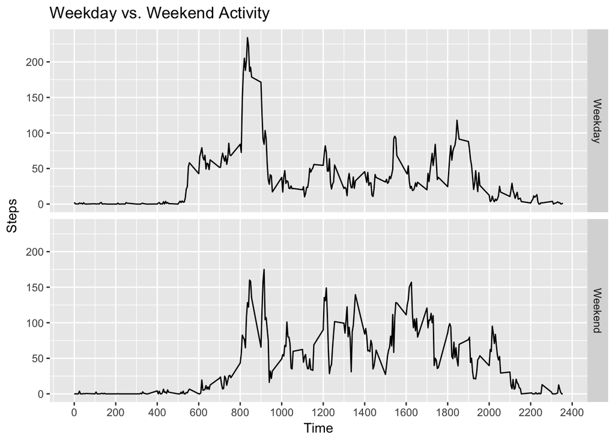

```r
day_diff <- activity
weekends <- c("Saturday", "Sunday")
day_diff$daytype <- ifelse(weekdays(as.Date(day_diff$date)) %in% weekends,
                            "Weekend", "Weekday")
day_diff$daytype <- as.factor(day_diff$daytype)

day_diff <- day_diff %>%
        group_by(interval, daytype) %>%
        summarise(avgsteps = mean(steps, na.rm = TRUE))

ggplot(day_diff) +
        geom_line(aes(interval, avgsteps)) +
        facet_grid(daytype~.) +
        labs(title = "Weekday vs. Weekend Activity",
             x = "Time", y = "Steps") +
        scale_x_continuous(breaks = seq(0, 2400, by= 200))
```

The graph shows that activity throughout the weekend days is on average higher than that of the weekday. Intervals with greatest level of activity, however, is between the hours of 8AM and 9Am during the weekdays.